# Prediction Assignment Writeup

Cristhian Antonio Toribio Amaro

September 06, 2020

# Executive Summary

Using devices such as Jawbone Up, Nike FuelBand, and Fitbit it is now possible to collect a large amount of data about personal activity relatively inexpensively. These type of devices are part of the quantified self movement - a group of enthusiasts who take measurements about themselves regularly to improve their health, to find patterns in their behavior, or because they are tech geeks. One thing that people regularly do is quantify how much of a particular activity they do, but they rarely quantify how well they do it. In this project, your goal will be to use data from accelerometers on the belt, forearm, arm, and dumbell of 6 participants. They were asked to perform barbell lifts correctly and incorrectly in 5 different ways. More information is available from the website here: http://groupware.les.inf.puc-rio.br/har (see the section on the Weight Lifting Exercise Dataset).

### Data source

The data for this project come from the Human Activity Recognition study, conducted by Pontif?cia Universidade Cat?lica - Rio de Janeiro. Read more: http://groupware.les.inf.puc-rio.br/har.

Ugulino, W.; Cardador, D.; Vega, K.; Velloso, E.; Milidiu, R.; Fuks, H. Wearable Computing: Accelerometers’ Data Classification of Body Postures and Movements. Proceedings of 21st Brazilian Symposium on Artificial Intelligence. Advances in Artificial Intelligence - SBIA 2012. In: Lecture Notes in Computer Science. , pp. 52-61. Curitiba, PR: Springer Berlin / Heidelberg, 2012. ISBN 978-3-642-34458-9. DOI: 10.1007/978-3-642-34459-6_6.

The training data for this project are available here:

https://d396qusza40orc.cloudfront.net/predmachlearn/pml-training.csv

The test data are available here:

https://d396qusza40orc.cloudfront.net/predmachlearn/pml-testing.csv

## Overview

This document contains two sections:

Analysis - where I provide the codes to download the cited training and testing datasets as well as clean them and also 3 machine learning algorithms - which regarding one different method of modeling.

# Analysis

Codes to load the libraries to be used:

```r
library("caret")
library("gbm")
```

```r
library("rpart")
library("rpart.plot")
library("RColorBrewer")
library("rattle")
library("randomForest")
```

Codes to download and read the train and test sets:

```r
download.file("https://d396qusza40orc.cloudfront.net/predmachlearn/pml-training.csv", dest="pml-training.csv", mode="wb")
download.file("https://d396qusza40orc.cloudfront.net/predmachlearn/pml-testing.csv", dest="pml-testing.csv", mode="wb")

dataTrain <- read.csv("pml-training.csv")
dataTest <- read.csv("pml-testing.csv")
head(dataTrain)
```

```
##   X user_name raw_timestamp_part_1 raw_timestamp_part_2   cvtd_timestamp
## 1 1  carlitos           1323084231               788290 05/12/2011 11:23
## 2 2  carlitos           1323084231               808298 05/12/2011 11:23
## 3 3  carlitos           1323084231               820366 05/12/2011 11:23
## 4 4  carlitos           1323084232               120339 05/12/2011 11:23
## 5 5  carlitos           1323084232               196328 05/12/2011 11:23
## 6 6  carlitos           1323084232               304277 05/12/2011 11:23
##   new_window num_window roll_belt pitch_belt yaw_belt total_accel_belt
## 1         no         11      1.41       8.07    -94.4                3
## 2         no         11      1.41       8.07    -94.4                3
## 3         no         11      1.42       8.07    -94.4                3
## 4         no         12      1.48       8.05    -94.4                3
## 5         no         12      1.48       8.07    -94.4                3
## 6         no         12      1.45       8.06    -94.4                3
##   kurtosis_roll_belt kurtosis_picth_belt kurtosis_yaw_belt skewness_roll_belt
```

[output cut: 251 more lines]

```r
head(dataTest)
```

```
##   X user_name raw_timestamp_part_1 raw_timestamp_part_2   cvtd_timestamp
## 1 1     pedro           1323095002               868349 05/12/2011 14:23
## 2 2    jeremy           1322673067               778725 30/11/2011 17:11
## 3 3    jeremy           1322673075               342967 30/11/2011 17:11
## 4 4    adelmo           1322832789               560311 02/12/2011 13:33
## 5 5    eurico           1322489635               814776 28/11/2011 14:13
## 6 6    jeremy           1322673149               510661 30/11/2011 17:12
##   new_window num_window roll_belt pitch_belt yaw_belt total_accel_belt
## 1         no         74    123.00      27.00    -4.75               20
## 2         no        431      1.02       4.87   -88.90                4
## 3         no        439      0.87       1.82   -88.50                5
## 4         no        194    125.00     -41.60   162.00               17
## 5         no        235      1.35       3.33   -88.60                3
## 6         no        504     -5.92       1.59   -87.70                4
##   kurtosis_roll_belt kurtosis_picth_belt kurtosis_yaw_belt skewness_roll_belt
```

[output cut: 251 more lines]

As we can see above, there’s some NA data in both datasets. I intend to proceed a cleaning of the dataset, but first I will partion the training set into two and check possibles Near Zero Variance Variables (it’s a necessity regarding the subject dataset, which has a great amount of Not Available datas, which I will refer as NA, and zero values).

Codes to partioning the training dataset into two: 70% for training and 30% for testing. I set seed to 13563 for reproducibility purposes.

```r
set.seed(13563)
inTrain <- createDataPartition(y=dataTrain$classe, p=0.7, list=FALSE)
training <- dataTrain[inTrain, ]
testing <- dataTrain[-inTrain, ]
dim(training)
```

```
## [1] 13737   160
```

```r
dim(testing)
```

```
## [1] 5885  160
```

Code to cheack possibles Near Zero Variance Variables:

```r
NZV_check <- nearZeroVar(training, saveMetrics = TRUE)
NZV_check
```

```
##                            freqRatio percentUnique zeroVar   nzv
## X                           1.000000  100.00000000   FALSE FALSE
## user_name                   1.120210    0.04367766   FALSE FALSE
## raw_timestamp_part_1        1.000000    6.09303341   FALSE FALSE
## raw_timestamp_part_2        1.250000   89.61927641   FALSE FALSE
## cvtd_timestamp              1.036609    0.14559220   FALSE FALSE
## new_window                 47.369718    0.01455922   FALSE  TRUE
## num_window                  1.000000    6.24590522   FALSE FALSE
## roll_belt                   1.222411    8.08764650   FALSE FALSE
## pitch_belt                  1.050725   12.21518527   FALSE FALSE
## yaw_belt                    1.039773   13.01594235   FALSE FALSE
## total_accel_belt            1.046961    0.20382907   FALSE FALSE
## kurtosis_roll_belt       1494.777778    2.00917231   FALSE  TRUE
## kurtosis_picth_belt       538.120000    1.65975104   FALSE  TRUE
## kurtosis_yaw_belt          47.369718    0.01455922   FALSE  TRUE
## skewness_roll_belt       1681.625000    1.99461309   FALSE  TRUE
## skewness_roll_belt.1      538.120000    1.75438596   FALSE  TRUE
## skewness_yaw_belt          47.369718    0.01455922   FALSE  TRUE
## max_roll_belt               1.000000    1.15017835   FALSE FALSE
## max_picth_belt              1.625000    0.13831259   FALSE FALSE
## max_yaw_belt              584.913043    0.42221737   FALSE  TRUE
## min_roll_belt               1.125000    1.05554342   FALSE FALSE
## min_pitch_belt              2.361111    0.10191454   FALSE FALSE
## min_yaw_belt              584.913043    0.42221737   FALSE  TRUE
## amplitude_roll_belt         1.240000    0.79347747   FALSE FALSE
## amplitude_pitch_belt        3.347826    0.08007571   FALSE FALSE
## amplitude_yaw_belt         50.766038    0.02911844   FALSE  TRUE
## var_total_accel_belt        1.222222    0.35670088   FALSE FALSE
## avg_roll_belt               1.100000    1.07738225   FALSE FALSE
## stddev_roll_belt            1.027778    0.42221737   FALSE FALSE
## var_roll_belt               1.800000    0.53141152   FALSE FALSE
## avg_pitch_belt              1.000000    1.31760938   FALSE FALSE
## stddev_pitch_belt           1.152174    0.29846400   FALSE FALSE
## var_pitch_belt              1.716981    0.42221737   FALSE FALSE
## avg_yaw_belt                1.125000    1.38312586   FALSE FALSE
## stddev_yaw_belt             1.594595    0.38581932   FALSE FALSE
## var_yaw_belt                1.689655    0.82987552   FALSE FALSE
## gyros_belt_x                1.004077    0.93906967   FALSE FALSE
## gyros_belt_y                1.105619    0.45133581   FALSE FALSE
## gyros_belt_z                1.077741    1.17929679   FALSE FALSE
```

[output cut: 106 more lines]

```
## stddev_pitch_forearm       66.000000    1.59423455   FALSE  TRUE
## var_pitch_forearm          66.000000    1.59423455   FALSE  TRUE
## avg_yaw_forearm            66.000000    1.59423455   FALSE  TRUE
## stddev_yaw_forearm         68.000000    1.57967533   FALSE  TRUE
## var_yaw_forearm            68.000000    1.57967533   FALSE  TRUE
## gyros_forearm_x             1.016086    2.08196841   FALSE FALSE
## gyros_forearm_y             1.011236    5.22675985   FALSE FALSE
## gyros_forearm_z             1.234727    2.09652763   FALSE FALSE
## accel_forearm_x             1.030769    5.65625682   FALSE FALSE
## accel_forearm_y             1.112676    7.11217879   FALSE FALSE
## accel_forearm_z             1.055046    4.01106501   FALSE FALSE
## magnet_forearm_x            1.017857   10.59911189   FALSE FALSE
## magnet_forearm_y            1.169492   13.27072869   FALSE FALSE
## magnet_forearm_z            1.000000   11.72017180   FALSE FALSE
## classe                      1.469526    0.03639805   FALSE FALSE
```

Codes to reset both training and testing sets without NZV:

```r
training <- training[, NZV_check$nzv==FALSE]
dim(training)
```

```
## [1] 13737   105
```

```r
NZV_check2 <- nearZeroVar(testing, saveMetrics = TRUE)
testing <- testing[, NZV_check2$nzv==FALSE]
dim(testing)
```

```
## [1] 5885  117
```

Theres a second transformation worth doing, which is removing the ID variable (the first column) so that it won’t interfer with Machine Learning Algorithms:

```r
training <- training[c(-1)]
testing <- testing[c(-1)]
```

I decided to clean the variables with more than 60% NAs.The threshold was chosen based at the 60% method, which I considered the most appropriate Training Threshold method for this particular dataset.

I also think worth to explain what’s going on: first, I will create a temporary subset to iterate in loop, then I will check for NA in every column in the dataset, select the columns under the 60% method and remove them.For closers, I will set it back to the proper dataset and remove the temp dataset. As you will see the code involved is plain logical reasoning.

Cleaning the training dataset:

```r
temp_train <- training
for (i in 1:length(training)) {
  if(sum(is.na(training[, i]))/nrow(training)>=0.6) {
    for (j in 1:length(temp_train)) {
      if(length(grep(names(training[i]), names(temp_train)[j]))==1){
        temp_train <- temp_train[, -j]
      }
    }
  }
}
dim(temp_train)
```

```
## [1] 13737    58
```

```r
training <- temp_train
rm(temp_train)
```

Cleaning the testing dataset:

```r
temp_test <- testing
for (i in 1:length(testing)) {
  if(sum(is.na(testing[, i]))/nrow(testing)>=0.6) {
    for (j in 1:length(temp_test)) {
      if(length(grep(names(testing[i]), names(temp_test)[j]))==1){
        temp_test <- temp_test[, -j]
      }
    }
  }
}
dim(temp_test)
```

```
## [1] 5885   58
```

```r
testing <- temp_test
rm(temp_test)
```

I chose to build 3 models. One model, using a random forest (“rf”) algorithm, the other, using a decision trees algorithm and a third, using a boosted trees algorithm - also known as generalized boosted regression (“gbm”).

Then, I intend to cross validate it predicting the outcomes and checking the accuracy of each model at the testing set.

Codes to build the models:

*Random Forest Algorithm*

```r
set.seed(13563)
modelFitRF <- randomForest(classe~., data = training)
```

Cross validating the model:

```r
predictFitRF <- predict(modelFitRF, testing, type = "class")
```

To check the accuracy:

```r
accuracy_FitRF <- confusionMatrix(predictFitRF, testing$classe)
accuracy_FitRF
```

```
## Confusion Matrix and Statistics
##
##           Reference
## Prediction    A    B    C    D    E
##          A 1673    1    0    0    0
##          B    1 1138    2    0    0
##          C    0    0 1023    5    0
##          D    0    0    1  959    5
##          E    0    0    0    0 1077
##
## Overall Statistics
##
##                Accuracy : 0.9975
##                  95% CI : (0.9958, 0.9986)
##     No Information Rate : 0.2845
##     P-Value [Acc > NIR] : < 2.2e-16
##
##                   Kappa : 0.9968
##
##  Mcnemar's Test P-Value : NA
##
## Statistics by Class:
##
##                      Class: A Class: B Class: C Class: D Class: E
## Sensitivity            0.9994   0.9991   0.9971   0.9948   0.9954
## Specificity            0.9998   0.9994   0.9990   0.9988   1.0000
## Pos Pred Value         0.9994   0.9974   0.9951   0.9938   1.0000
## Neg Pred Value         0.9998   0.9998   0.9994   0.9990   0.9990
## Prevalence             0.2845   0.1935   0.1743   0.1638   0.1839
## Detection Rate         0.2843   0.1934   0.1738   0.1630   0.1830
## Detection Prevalence   0.2845   0.1939   0.1747   0.1640   0.1830
## Balanced Accuracy      0.9996   0.9992   0.9980   0.9968   0.9977
```

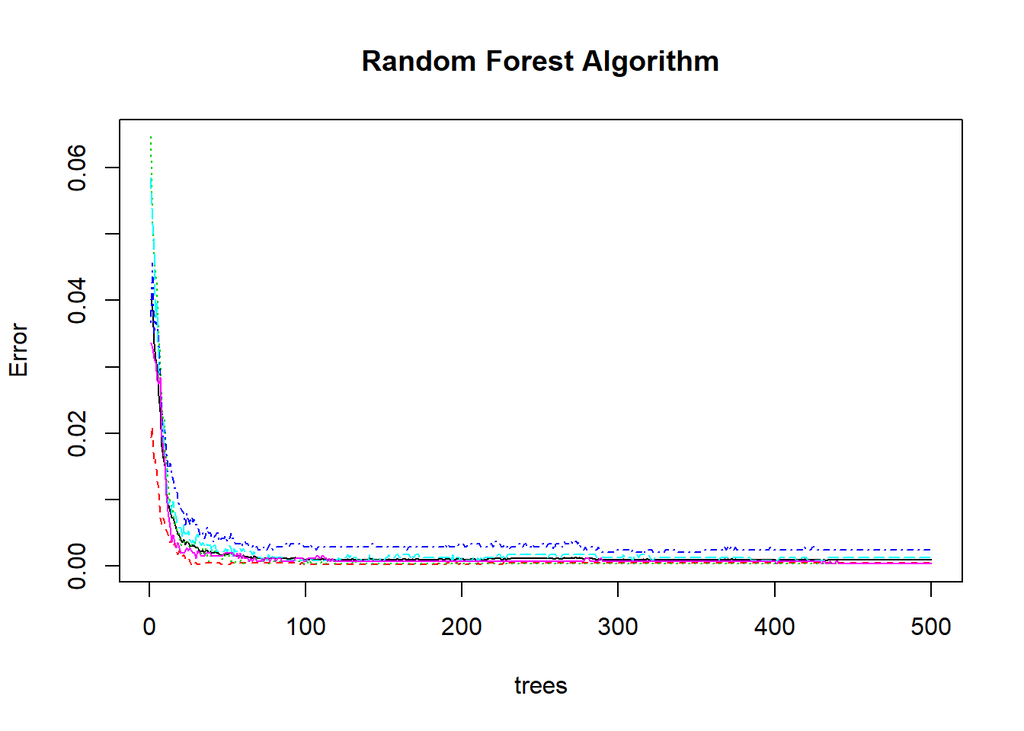

```r
plot(modelFitRF, main = "Random Forest Algorithm")
```

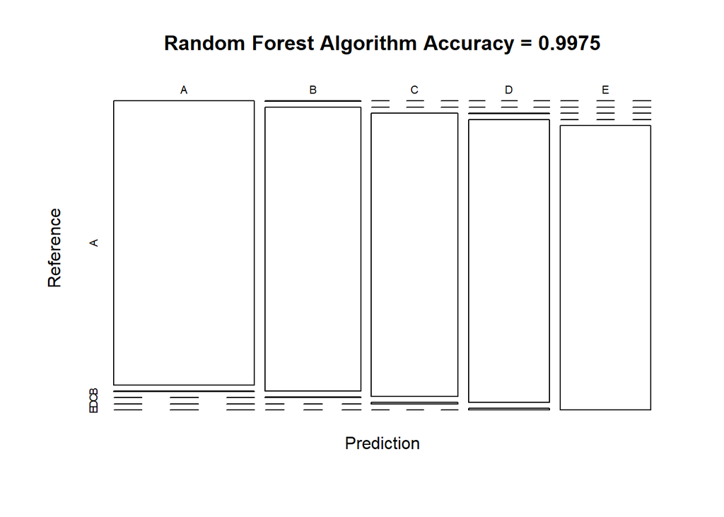

```r
plot(accuracy_FitRF$table, col = accuracy_FitRF$byClass, main = paste("Random Forest Algorithm Accuracy =", round(accuracy_FitRF$overall['Accuracy'], 4)))
```

*Decision Tree Algorithm*

[figure not shown]

```r
set.seed(13563)
modelFitDT <- rpart(classe ~., data = training, method = "class")
fancyRpartPlot(modelFitDT)
```

Cross validating the model:

```r
predictFitDT <- predict(modelFitDT, testing, type = "class")
```

To check the accuracy:

```r
accuracy_FitDT <- confusionMatrix(predictFitDT, testing$classe)
accuracy_FitDT
```

```
## Confusion Matrix and Statistics
##
##           Reference
## Prediction    A    B    C    D    E
##          A 1611   42    6    0    0
##          B   52  958   77   49    0
##          C   11  130  927   94   41
##          D    0    9   10  683   63
##          E    0    0    6  138  978
##
## Overall Statistics
##
##                Accuracy : 0.8763
##                  95% CI : (0.8676, 0.8846)
##     No Information Rate : 0.2845
##     P-Value [Acc > NIR] : < 2.2e-16
##
##                   Kappa : 0.8435
##
##  Mcnemar's Test P-Value : NA
##
## Statistics by Class:
##
##                      Class: A Class: B Class: C Class: D Class: E
## Sensitivity            0.9624   0.8411   0.9035   0.7085   0.9039
## Specificity            0.9886   0.9625   0.9432   0.9833   0.9700
## Pos Pred Value         0.9711   0.8433   0.7706   0.8928   0.8717
## Neg Pred Value         0.9851   0.9619   0.9789   0.9451   0.9782
## Prevalence             0.2845   0.1935   0.1743   0.1638   0.1839
## Detection Rate         0.2737   0.1628   0.1575   0.1161   0.1662
## Detection Prevalence   0.2819   0.1930   0.2044   0.1300   0.1907
## Balanced Accuracy      0.9755   0.9018   0.9234   0.8459   0.9370
```

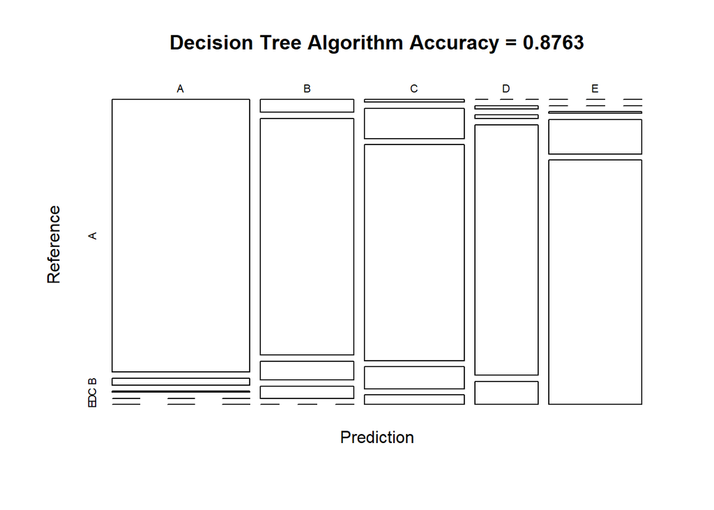

```r
plot(accuracy_FitDT$table, col = accuracy_FitDT$byClass, main = paste("Decision Tree Algorithm Accuracy =", round(accuracy_FitDT$overall['Accuracy'], 4)))
```

*Boosted Trees Algorithm*

To load the library needed and set seed to reproducibility.

```r
library(plyr)
set.seed(13563)
```

I usually don’t use the trainControl function from the caret package because one of its uses is allow to perform a variety of cross validation. As the Confusion Matrix and the predict function allow us to do the same, I usually don’t see the point to trainControl the model. However, in this case the model took too long to fit and almost “hijacked” my computer memory, so I used it to cut it short.

```r
FitControlGBM <- trainControl(method = "repeatedcv", number = 5, repeats = 1)

modelFitGBM <- train(classe~., data = training, method = "gbm", trControl = FitControlGBM, verbose = FALSE)

FinalmodelFitGBM <- modelFitGBM$finalModel
```

Cross validating the model:

```r
predictFitGBM <- predict(modelFitGBM, newdata = testing)
```

To check the accuracy:

```r
accuracy_FitGBM <- confusionMatrix(predictFitGBM, testing$classe)
accuracy_FitGBM
```

```
## Confusion Matrix and Statistics
##
##           Reference
## Prediction    A    B    C    D    E
##          A 1672    1    0    0    0
##          B    2 1138    2    0    0
##          C    0    0 1016    3    0
##          D    0    0    8  960    4
##          E    0    0    0    1 1078
##
## Overall Statistics
##
##                Accuracy : 0.9964
##                  95% CI : (0.9946, 0.9978)
##     No Information Rate : 0.2845
##     P-Value [Acc > NIR] : < 2.2e-16
##
##                   Kappa : 0.9955
##
##  Mcnemar's Test P-Value : NA
##
## Statistics by Class:
##
##                      Class: A Class: B Class: C Class: D Class: E
## Sensitivity            0.9988   0.9991   0.9903   0.9959   0.9963
## Specificity            0.9998   0.9992   0.9994   0.9976   0.9998
## Pos Pred Value         0.9994   0.9965   0.9971   0.9877   0.9991
## Neg Pred Value         0.9995   0.9998   0.9979   0.9992   0.9992
## Prevalence             0.2845   0.1935   0.1743   0.1638   0.1839
## Detection Rate         0.2841   0.1934   0.1726   0.1631   0.1832
## Detection Prevalence   0.2843   0.1941   0.1732   0.1652   0.1833
## Balanced Accuracy      0.9993   0.9991   0.9948   0.9967   0.9980
```

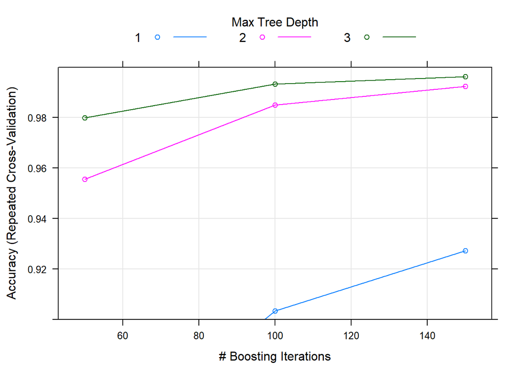

```r
plot(modelFitGBM, ylim = c(0.9, 1))
```

# Predicting Results

Code to proceed the prediction:

```r
prediction_results <- predict(modelFitRF, testing, type = "class")
prediction_results
```

```
##     2     3     6     8    10    16    18    19    24    25    27    29    30
##     A     A     A     A     A     A     A     A     A     A     A     A     A
##    42    55    57    64    72    77    81    82    85    90    95    97    99
##     A     A     A     A     A     A     A     A     A     A     A     A     A
##   104   106   121   123   125   128   130   135   140   145   148   151   153
##     A     A     A     A     A     A     A     A     A     A     A     A     A
##   154   157   158   159   160   161   164   170   172   176   179   183   184
##     A     A     A     A     A     A     A     A     A     A     A     A     A
##   188   198   200   203   204   208   210   213   214   217   223   225   226
##     A     A     A     A     A     A     A     A     A     A     A     A     A
##   228   230   233   234   239   243   245   246   251   260   263   265   266
##     A     A     A     A     A     A     A     A     A     A     A     A     A
##   268   272   274   284   287   288   293   294   295   297   301   305   315
##     A     A     A     A     A     A     A     A     A     A     A     A     A
##   316   319   324   335   341   343   344   345   347   350   356   364   367
##     A     A     A     A     A     A     A     A     A     A     A     A     A
##   372   375   378   379   390   392   393   395   396   403   404   405   410
##     A     A     A     A     A     A     A     A     A     A     A     A     A
##   414   417   419   420   421   422   427   429   432   433   437   438   441
##     A     A     A     A     A     A     A     A     A     A     A     A     A
##   443   447   454   456   457   459   462   463   466   469   472   475   478
##     A     A     A     A     A     A     A     A     A     A     A     A     A
##   479   481   484   485   486   490   492   494   495   501   502   503   505
##     A     A     A     A     A     A     A     A     A     A     A     A     A
##   508   511   519   531   532   533   535   538   539   540   543   547   555
##     A     A     A     A     A     A     A     A     A     A     A     A     A
##   556   558   559   560   565   573   575   580   583   590   592   600   602
##     A     A     A     A     A     A     A     A     A     A     A     A     A
##   623   628   634   638   639   640   645   646   647   650   654   658   666
##     A     A     A     A     A     A     A     A     A     A     A     A     A
##   667   669   670   676   677   678   680   685   687   696   697   700   707
##     A     A     A     A     A     A     A     A     A     A     A     A     A
##   712   714   716   726   727   729   735   738   747   757   763   765   766
##     A     A     A     A     A     A     A     A     A     A     A     A     A
##   773   774   775   778   779   783   786   787   790   797   798   799   801
##     A     A     A     A     A     A     A     A     A     A     A     A     A
##   802   803   809   811   813   814   816   823   824   828   831   836   837
##     A     A     A     A     A     A     A     A     A     A     A     A     A
##   839   841   844   848   849   857   860   869   871   872   880   883   884
##     A     A     A     A     A     A     A     A     A     A     A     A     A
```

[output cut: 852 more lines]

```
## 19348 19354 19356 19359 19361 19362 19364 19367 19368 19371 19380 19381 19382
##     E     E     E     E     E     E     E     E     E     E     E     E     E
## 19383 19384 19385 19387 19388 19389 19390 19391 19401 19402 19404 19420 19422
##     E     E     E     E     E     E     E     E     E     E     E     E     E
## 19430 19433 19437 19439 19440 19443 19444 19445 19448 19456 19459 19460 19462
##     E     E     E     E     E     E     E     E     E     E     E     E     E
## 19463 19475 19482 19489 19490 19494 19497 19502 19504 19508 19513 19520 19521
##     E     E     E     E     E     E     E     E     E     E     E     E     E
## 19523 19524 19526 19528 19541 19544 19545 19547 19548 19553 19554 19557 19558
##     E     E     E     E     E     E     E     E     E     E     E     E     E
## 19560 19563 19566 19568 19569 19578 19579 19581 19585 19590 19591 19592 19594
##     E     E     E     E     E     E     E     E     E     E     E     E     E
## 19596 19602 19605 19606 19607 19610 19614 19615 19618
##     E     E     E     E     E     E     E     E     E
## Levels: A B C D E
```

To generate file texts with predictions to submit for assignment. Here a warning is necessary, the code will create about 5,885 text files, so handle carefully.

```r
file_to_assignment <- function(x){
  n=length(x)
  for (i in 1:n) {
    filename = paste0("problem_id_", i, ".txt")
    write.table(x[i], file = filename, quote = FALSE, row.names = FALSE, col.names = FALSE)
  }
}
```

To create the files, use the function: file_to_assignment(prediction_results)